# Atividade para aula 15

Prof. Frega

2025-04-02

```r
knitr::opts_chunk$set(echo = TRUE)
library(magrittr)
include.code = TRUE
source("https://raw.githubusercontent.com/jrfrega/2025/refs/heads/main/mhist.R")
```

# 1 Questão 1

1. Examine a variável dependente. Necessita de alguma transformação? Por que?
2. Faça o gráfico da variável $y$ contra a variável $x$. Proponha uma possível forma funcional.
3. Teste um modelo de relação linear. Como ficou o ajustamento? Que gráficos você pode fazer?
4. Você proporia algum modelo diferente da relação linear? Se sim, teste.

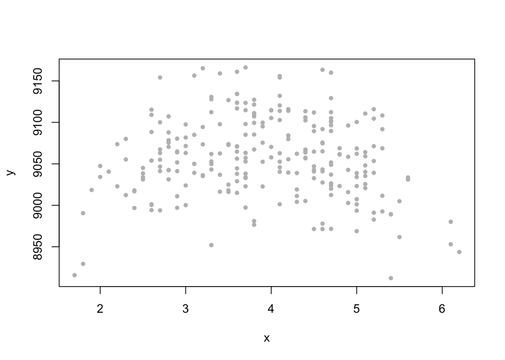

```r
set.seed(10)
x = rnorm(250, 4, 1)
y = 150*x - 20.5*x^2 +8800 + 40*rnorm(x)
x = x %>% round(1)
y = y %>% round(1)
data.q1 = data.frame(y, x)
plot(x, y, pch = 20, col = "gray")
```

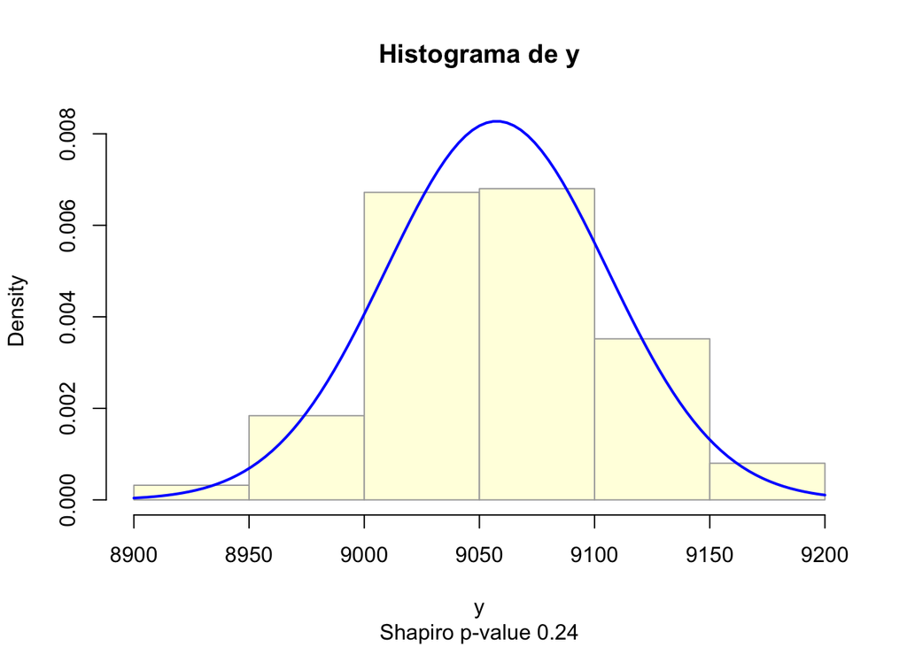

```r
mhist(y)
```

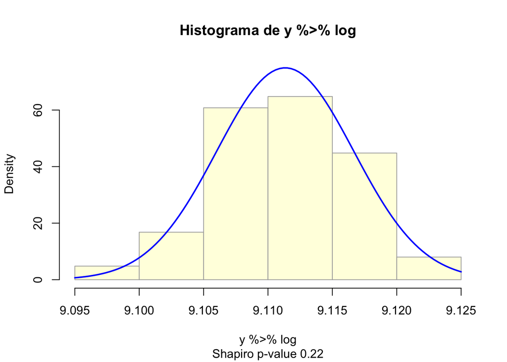

```r
mhist(y %>% log)
```

```r
m = lm(y~x)
library(lmtest)
reset(m)
```

```
##
##  RESET test
##
## data:  m
## RESET = 31.63, df1 = 2, df2 = 246, p-value = 5.961e-13
```

```r
shapiro.test(m$residuals %>% scale)
```

```
##
##  Shapiro-Wilk normality test
##
## data:  m$residuals %>% scale
## W = 0.99193, p-value = 0.1879
```

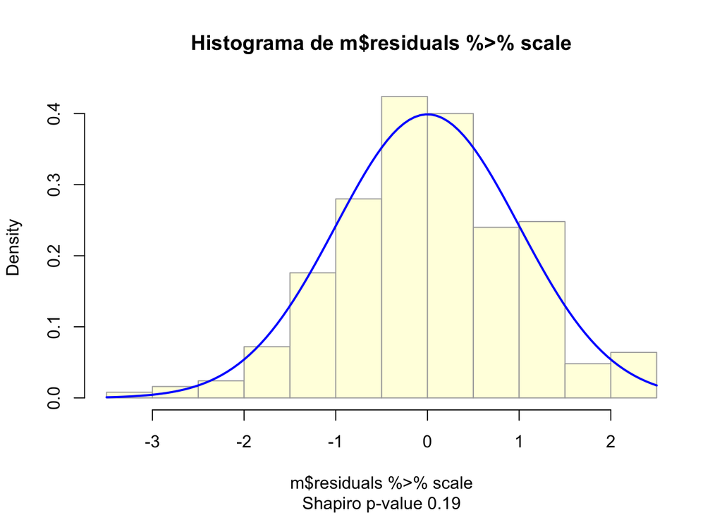

```r
mhist(m$residuals %>% scale)
```

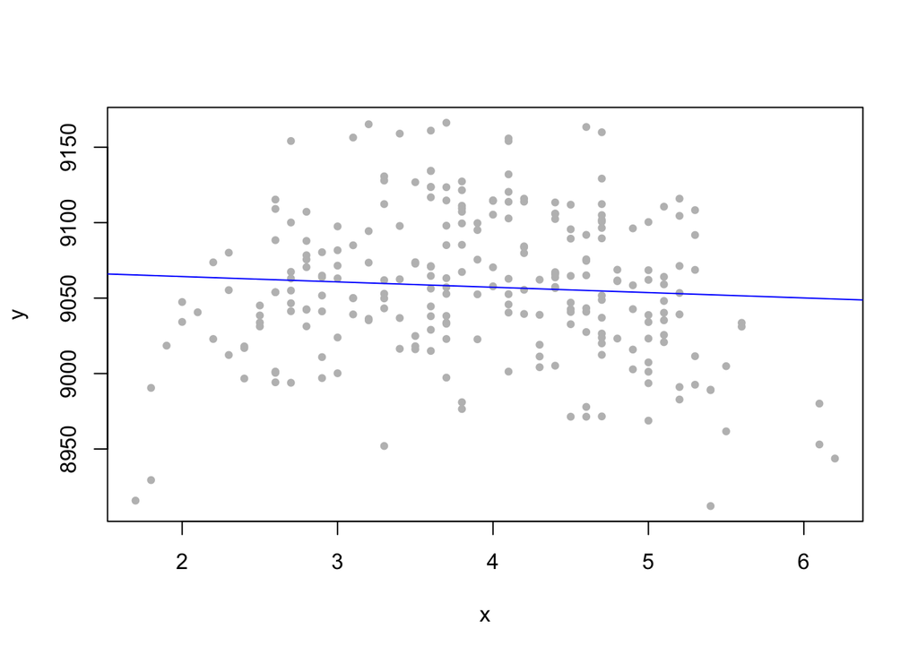

```r
plot(x, y, pch = 20, col = "gray")
abline(m, col = "blue")
```

```r
m2 = lm(y~x+I(x^2))
reset(m2)
```

```
##
##  RESET test
##
## data:  m2
## RESET = 0.16152, df1 = 2, df2 = 245, p-value = 0.8509
```

```r
shapiro.test(m2$residuals %>% scale)
```

```
##
##  Shapiro-Wilk normality test
##
## data:  m2$residuals %>% scale
## W = 0.99586, p-value = 0.7466
```

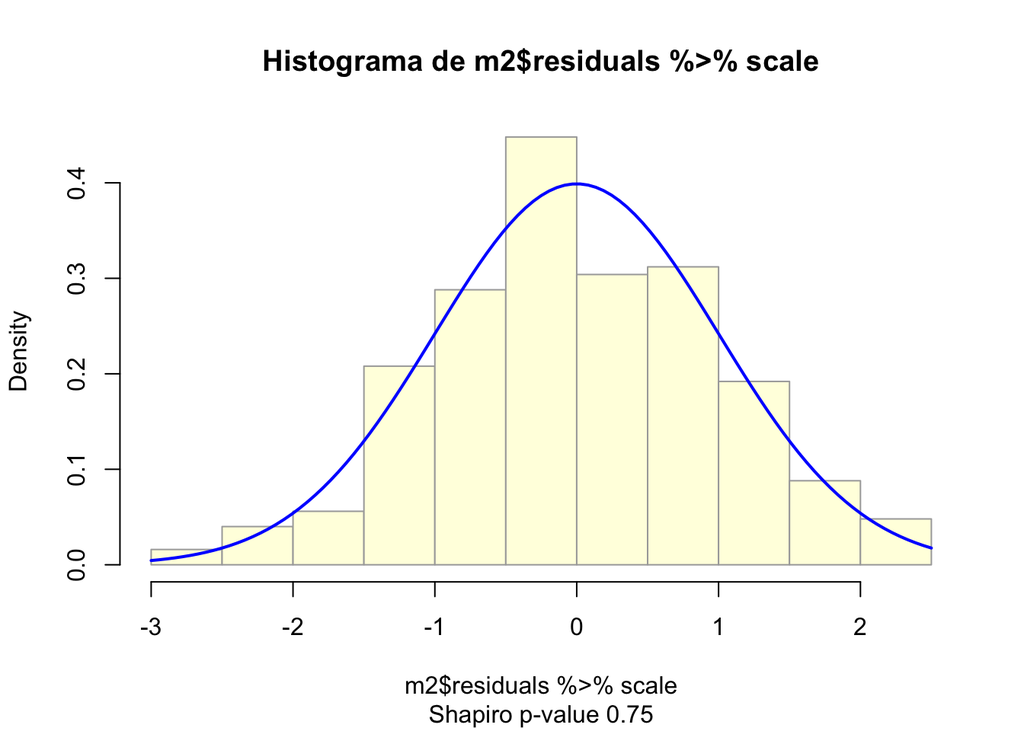

```r
mhist(m2$residuals %>% scale)
```

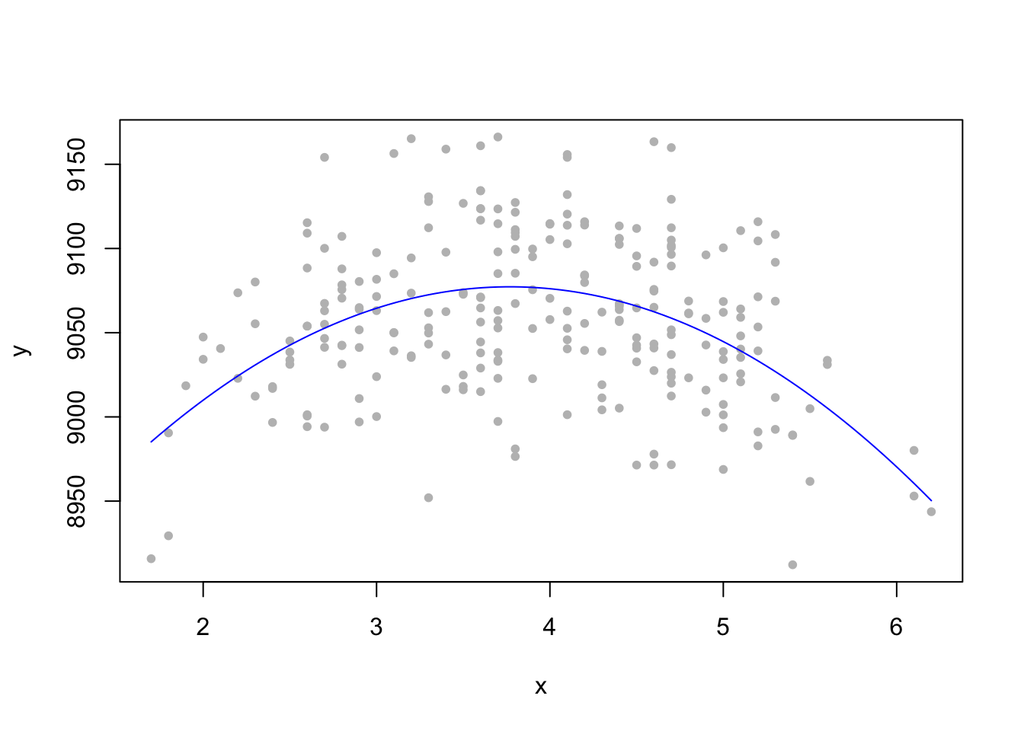

```r
plot(x, y, pch = 20, col = "gray")
.x = seq(min(x), max(x), length.out = 100)
.y = predict(m2, data.frame(x = .x))
lines(.x, .y, col = "blue")
```

# 2 Questão 2

No modelo proposto, a variável y é explicada por x. Espera-se uma relação de grau mais elevado. Monte o percurso investigativo e explique cada etapa.

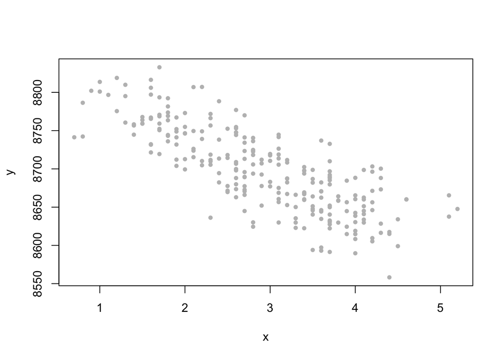

```r
set.seed(10)
x = rnorm(250, 3, 1)
y = 4.4*x^3+ 20*x - 32.5*x^2 +8800 + 30*rnorm(x)
x = x %>% round(1)
y = y %>% round(1)
data.q2 = data.frame(y, x)
plot(x, y, pch = 20, col = "gray")
```

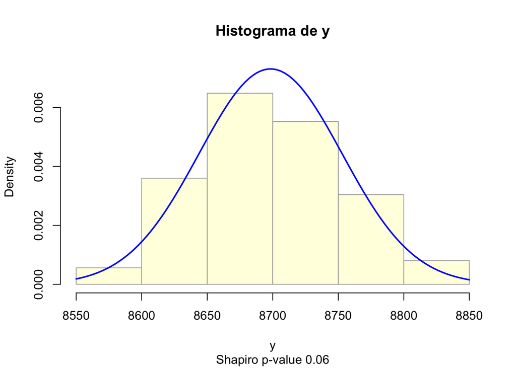

```r
mhist(y)
```

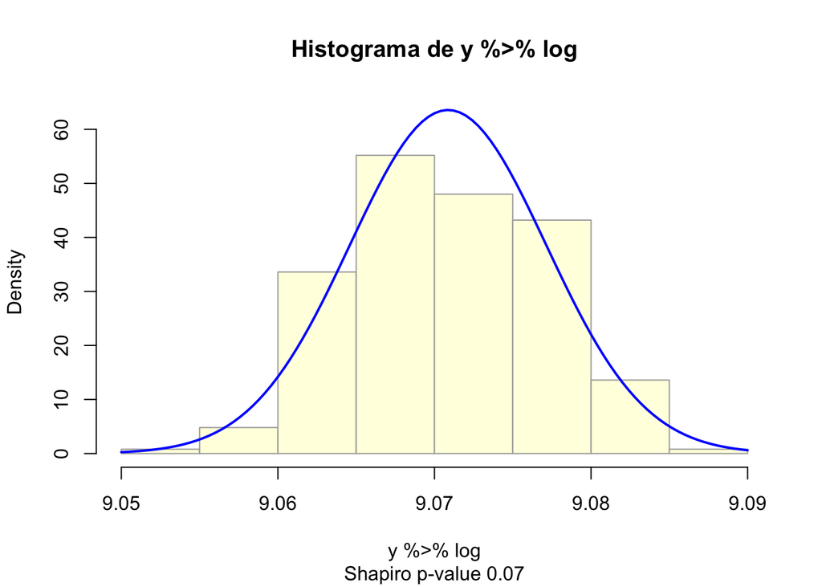

```r
mhist(y %>% log)
```

```r
m = lm(y~x)
library(lmtest)
reset(m)
```

```
##
##  RESET test
##
## data:  m
## RESET = 8.1831, df1 = 2, df2 = 246, p-value = 0.0003625
```

```r
shapiro.test(m$residuals %>% scale)
```

```
##
##  Shapiro-Wilk normality test
##
## data:  m$residuals %>% scale
## W = 0.9952, p-value = 0.6272
```

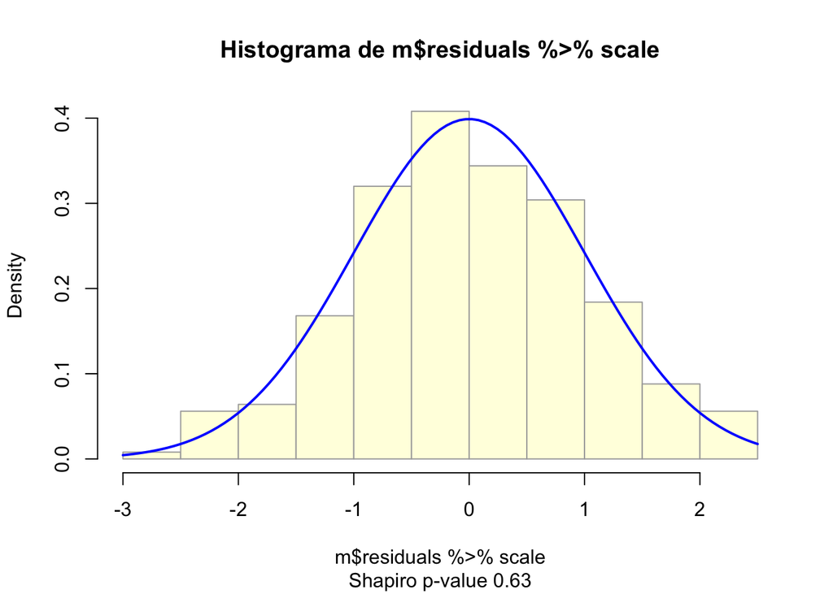

```r
mhist(m$residuals %>% scale)
```

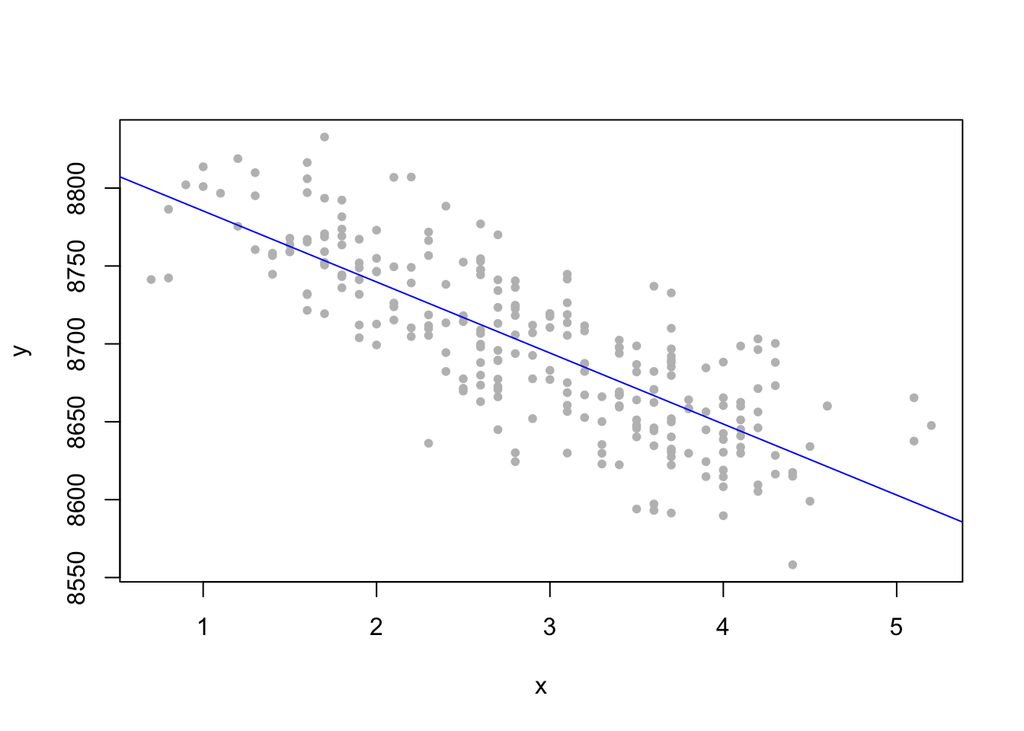

```r
plot(x, y, pch = 20, col = "gray")
abline(m, col = "blue")
```

```r
m2 = lm(y~x+I(x^2))
reset(m2)
```

```
##
##  RESET test
##
## data:  m2
## RESET = 5.723, df1 = 2, df2 = 245, p-value = 0.003723
```

```r
shapiro.test(m2$residuals %>% scale)
```

```
##
##  Shapiro-Wilk normality test
##
## data:  m2$residuals %>% scale
## W = 0.99399, p-value = 0.4198
```

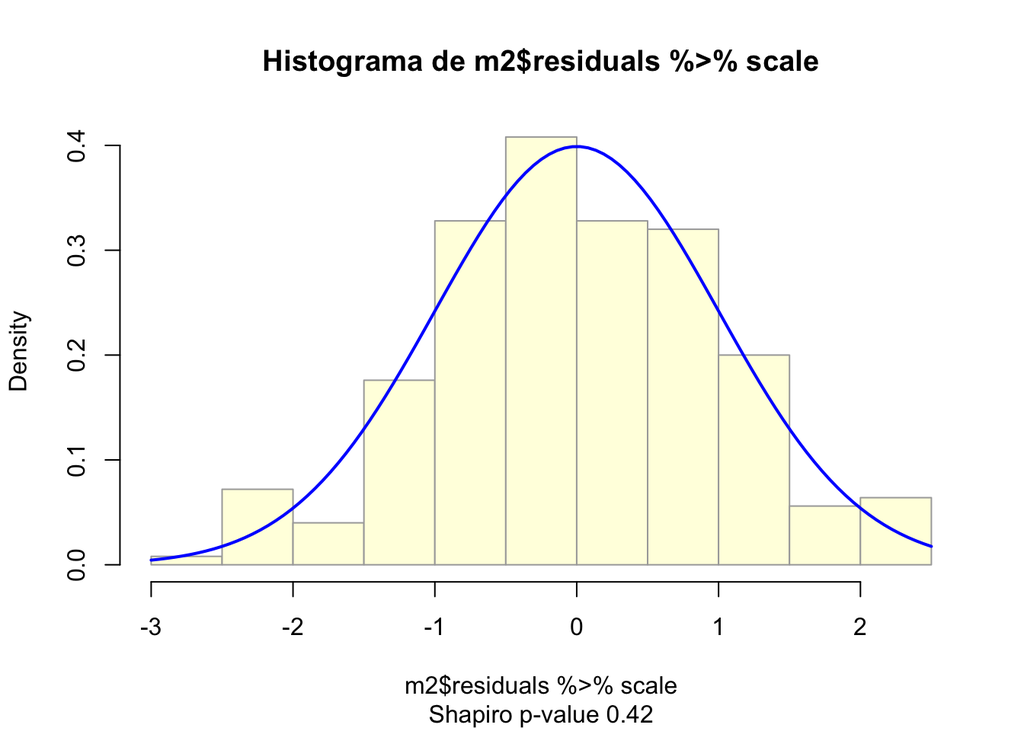

```r
mhist(m2$residuals %>% scale)
```

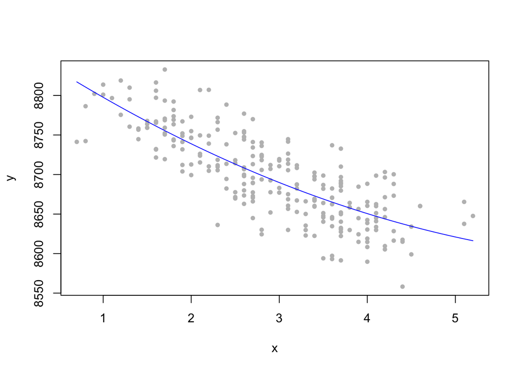

```r
plot(x, y, pch = 20, col = "gray")
.x = seq(min(x), max(x), length.out = 100)
.y = predict(m2, data.frame(x = .x))
lines(.x, .y, col = "blue")
```

```r
m3 = lm(y~x+I(x^2)+I(x^3))
reset(m3)
```

```
##
##  RESET test
##
## data:  m3
## RESET = 0.79521, df1 = 2, df2 = 244, p-value = 0.4527
```

```r
shapiro.test(m3$residuals %>% scale)
```

```
##
##  Shapiro-Wilk normality test
##
## data:  m3$residuals %>% scale
## W = 0.99525, p-value = 0.6366
```

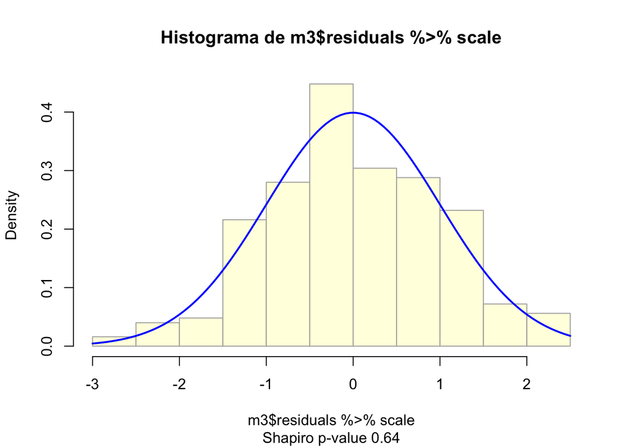

```r
mhist(m3$residuals %>% scale)
```

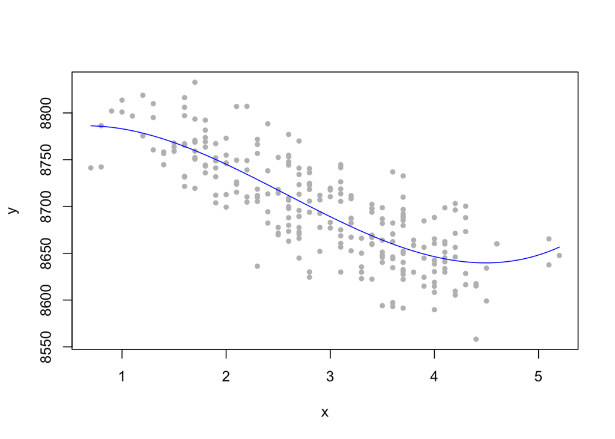

```r
plot(x, y, pch = 20, col = "gray")
.x = seq(min(x), max(x), length.out = 100)
.y = predict(m3, data.frame(x = .x))
lines(.x, .y, col = "blue")
```

```r
stargazer::stargazer(m, m2, m3, type = "text")
```

```
##
## ==============================================================================================
##                                                Dependent variable:
##                     --------------------------------------------------------------------------
##                                                         y
##                               (1)                      (2)                      (3)
## ----------------------------------------------------------------------------------------------
## x                          -45.599***               -73.368***                 46.522
##                             (2.224)                  (12.027)                 (38.610)
##
## I(x2)                                                4.868**                 -40.319***
##                                                      (2.073)                  (14.005)
##
## I(x3)                                                                         5.215***
##                                                                               (1.599)
##
## Constant                  8,830.946***             8,866.160***             8,771.642***
##                             (6.804)                  (16.440)                 (33.168)
##
## ----------------------------------------------------------------------------------------------
## Observations                  250                      250                      250
## R2                           0.629                    0.637                    0.652
## Adjusted R2                  0.627                    0.634                    0.648
## Residual Std. Error    33.330 (df = 248)        33.031 (df = 247)        32.405 (df = 246)
## F Statistic         420.230*** (df = 1; 248) 216.699*** (df = 2; 247) 153.647*** (df = 3; 246)
## ==============================================================================================
## Note:                                                              *p<0.1; **p<0.05; ***p<0.01
```

# 3 Questão 3

No modelo proposto, a variável y é explicada por X1, X2 e X3. Espera-se relações de segundo ou terceiro grau para as variáveis independentes. Monte o percurso investigativo e explique cada etapa.

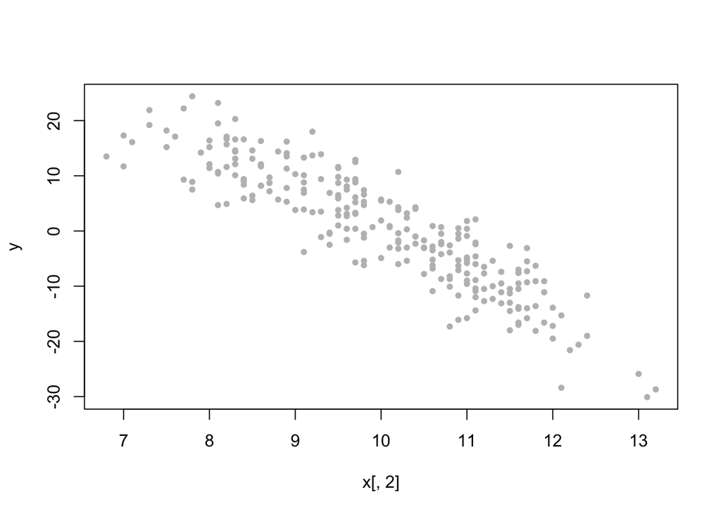

```r
set.seed(10)
x = MASS::mvrnorm(250, c(10, 10, 10), diag(c(1, 2, 1.5)))
y = 10+3*rnorm(x[,1])+x%*%matrix(c(-1, 2, 3), ncol = 1)-0.5*x[,2]^2
x = x %>% round(1) + 0.1
y = y %>% as.numeric %>% round(1)
data = data.frame(y, x)
data.q3 = data
plot(x[,2], y, pch = 20, col = "gray")
```

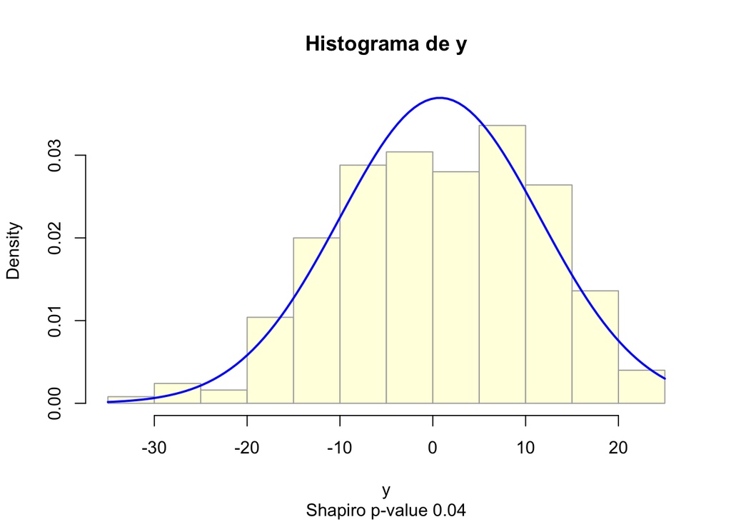

```r
mhist(y)
```

```r
m = lm(y~., data)
library(lmtest)
reset(m)
```

```
##
##  RESET test
##
## data:  m
## RESET = 17.101, df1 = 2, df2 = 244, p-value = 1.121e-07
```

```r
shapiro.test(m$residuals %>% scale)
```

```
##
##  Shapiro-Wilk normality test
##
## data:  m$residuals %>% scale
## W = 0.9915, p-value = 0.1568
```

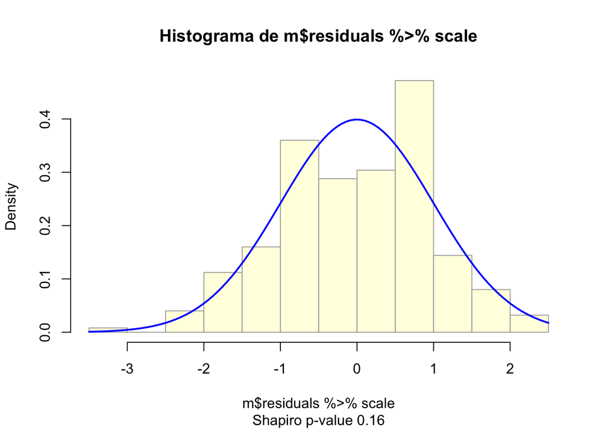

```r
mhist(m$residuals %>% scale)
```

```r
summary(m)
```

```
##
## Call:
## lm(formula = y ~ ., data = data)
##
## Residuals:
##     Min      1Q  Median      3Q     Max
## -9.2353 -1.9166  0.0829  2.0571  7.2043
##
## Coefficients:
##             Estimate Std. Error t value Pr(>|t|)
## (Intercept)  54.5813     2.6154  20.869  < 2e-16 ***
## X1           -0.7640     0.1787  -4.276 2.72e-05 ***
## X2           -7.5397     0.1395 -54.052  < 2e-16 ***
## X3            2.8515     0.1418  20.115  < 2e-16 ***
## ---
## Signif. codes:  0 '***' 0.001 '**' 0.01 '*' 0.05 '.' 0.1 ' ' 1
##
## Residual standard error: 2.929 on 246 degrees of freedom
## Multiple R-squared:  0.9273, Adjusted R-squared:  0.9265
## F-statistic:  1047 on 3 and 246 DF,  p-value: < 2.2e-16
```

```r
m2 = lm(y~.+I(X1^2)+I(X2^2)+I(X3^2), data)
reset(m2)
```

```
##
##  RESET test
##
## data:  m2
## RESET = 0.46358, df1 = 2, df2 = 241, p-value = 0.6296
```

```r
shapiro.test(m2$residuals %>% scale)
```

```
##
##  Shapiro-Wilk normality test
##
## data:  m2$residuals %>% scale
## W = 0.99568, p-value = 0.7152
```

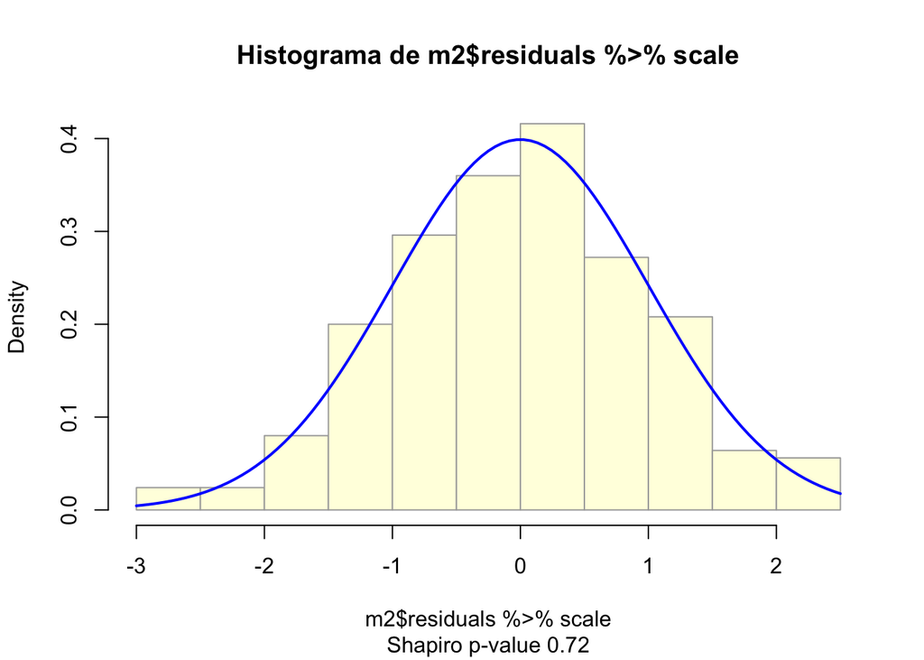

```r
mhist(m2$residuals %>% scale)
```

```r
summary(m2)
```

```
##
## Call:
## lm(formula = y ~ . + I(X1^2) + I(X2^2) + I(X3^2), data = data)
##
## Residuals:
##     Min      1Q  Median      3Q     Max
## -7.5765 -1.8879  0.1015  1.6359  6.3066
##
## Coefficients:
##             Estimate Std. Error t value Pr(>|t|)
## (Intercept) 13.23041   14.68245   0.901  0.36843
## X1          -5.59739    2.10564  -2.658  0.00838 **
## X2           5.24744    1.63951   3.201  0.00155 **
## X3           3.53278    1.48797   2.374  0.01836 *
## I(X1^2)      0.23877    0.10387   2.299  0.02237 *
## I(X2^2)     -0.64478    0.08260  -7.806 1.76e-13 ***
## I(X3^2)     -0.03442    0.07294  -0.472  0.63742
## ---
## Signif. codes:  0 '***' 0.001 '**' 0.01 '*' 0.05 '.' 0.1 ' ' 1
##
## Residual standard error: 2.615 on 243 degrees of freedom
## Multiple R-squared:  0.9428, Adjusted R-squared:  0.9414
## F-statistic: 667.4 on 6 and 243 DF,  p-value: < 2.2e-16
```

```r
mfinal = lm(y~.+I(X1^2)+I(X2^2), data)
reset(mfinal)
```

```
##
##  RESET test
##
## data:  mfinal
## RESET = 0.42156, df1 = 2, df2 = 242, p-value = 0.6565
```

```r
shapiro.test(mfinal$residuals %>% scale)
```

```
##
##  Shapiro-Wilk normality test
##
## data:  mfinal$residuals %>% scale
## W = 0.99555, p-value = 0.6913
```

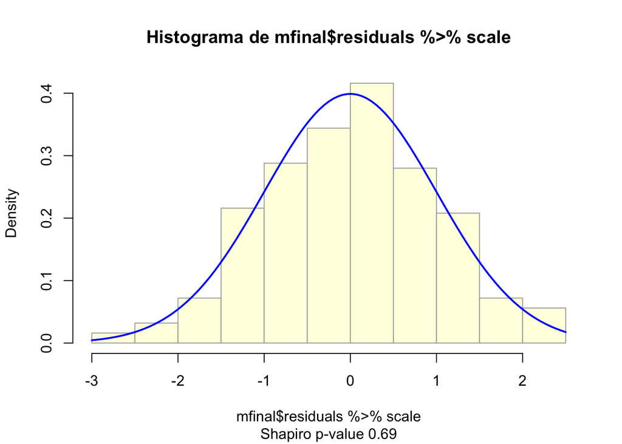

```r
mhist(mfinal$residuals %>% scale)
```

```r
summary(mfinal)
```

```
##
## Call:
## lm(formula = y ~ . + I(X1^2) + I(X2^2), data = data)
##
## Residuals:
##     Min      1Q  Median      3Q     Max
## -7.5835 -1.9380  0.0993  1.6745  6.2879
##
## Coefficients:
##             Estimate Std. Error t value Pr(>|t|)
## (Intercept) 16.37253   13.06499   1.253  0.21135
## X1          -5.47008    2.08496  -2.624  0.00925 **
## X2           5.20461    1.63439   3.184  0.00164 **
## X3           2.83315    0.12643  22.409  < 2e-16 ***
## I(X1^2)      0.23189    0.10268   2.258  0.02480 *
## I(X2^2)     -0.64277    0.08236  -7.804 1.75e-13 ***
## ---
## Signif. codes:  0 '***' 0.001 '**' 0.01 '*' 0.05 '.' 0.1 ' ' 1
##
## Residual standard error: 2.611 on 244 degrees of freedom
## Multiple R-squared:  0.9427, Adjusted R-squared:  0.9416
## F-statistic: 803.4 on 5 and 244 DF,  p-value: < 2.2e-16
```

# 4 Questão 4

No modelo proposto, a variável y é explicada por X1, X2 e X3. Espera-se coeficientes positivos para X1 e X2 e investiga-se uma possível relacão de moderação de X2 para o efeito de X1. Monte o percurso investigativo e explique cada etapa.

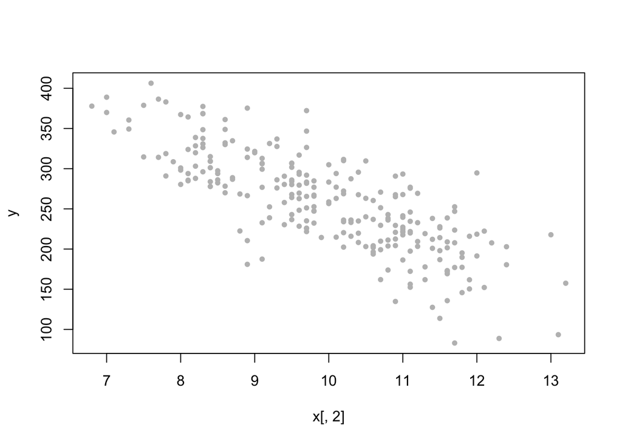

```r
set.seed(10)
x = MASS::mvrnorm(250, c(10, 10, 10), diag(c(1, 2, 1.5)))
y = 3*x[,1]+2*x[,2]-4*x[,1]*x[,2]+rnorm(x[,1])+600
x = x %>% round(1) + 0.1
y = y %>% as.numeric %>% round(1)
data = data.frame(y, x)
data.q4 = data
plot(x[,2], y, pch = 20, col = "gray")
```

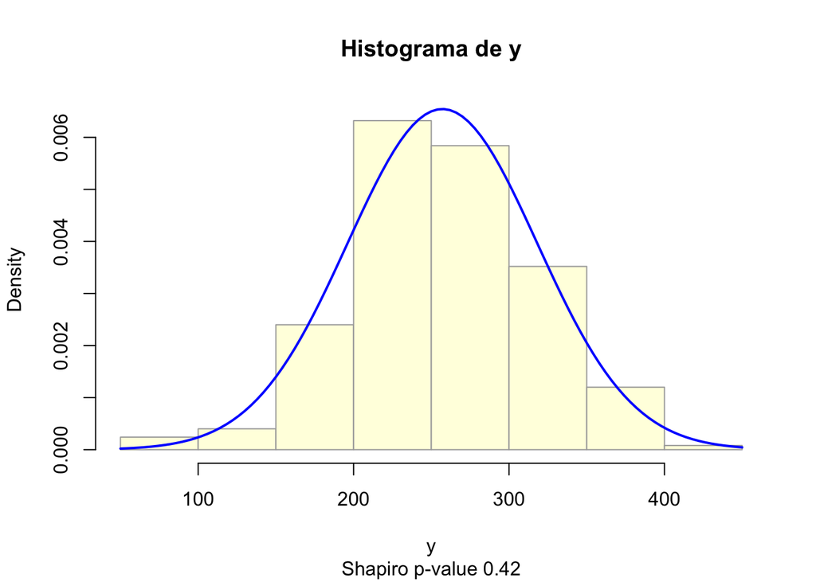

```r
mhist(y)
```

```r
m = lm(y~X1+X2+X3+X1:X2, data)
library(lmtest)
reset(m)
```

```
##
##  RESET test
##
## data:  m
## RESET = 0.27176, df1 = 2, df2 = 243, p-value = 0.7623
```

```r
shapiro.test(m$residuals %>% scale)
```

```
##
##  Shapiro-Wilk normality test
##
## data:  m$residuals %>% scale
## W = 0.99472, p-value = 0.5408
```

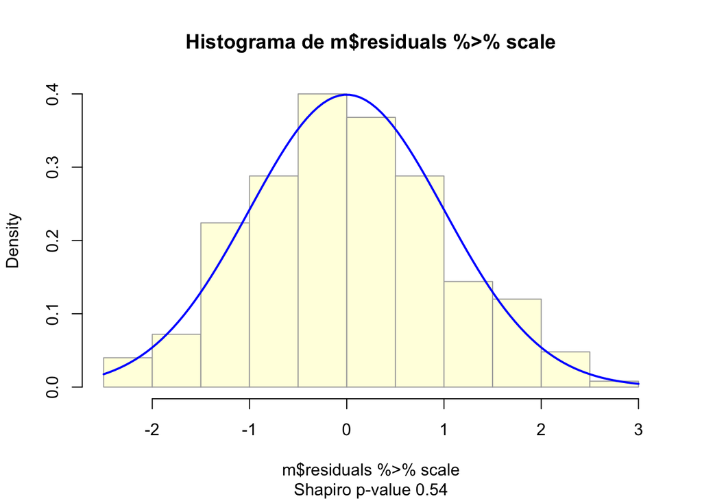

```r
mhist(m$residuals %>% scale)
```

```r
summary(m)
```

```
##
## Call:
## lm(formula = y ~ X1 + X2 + X3 + X1:X2, data = data)
##
## Residuals:
##     Min      1Q  Median      3Q     Max
## -3.9772 -1.1529 -0.0508  1.0849  4.1019
##
## Coefficients:
##              Estimate Std. Error t value Pr(>|t|)
## (Intercept) 600.06577    7.51691  79.829  < 2e-16 ***
## X1            3.34391    0.73687   4.538  8.9e-06 ***
## X2            2.39834    0.75479   3.177  0.00168 **
## X3           -0.12768    0.08015  -1.593  0.11247
## X1:X2        -3.98678    0.07483 -53.276  < 2e-16 ***
## ---
## Signif. codes:  0 '***' 0.001 '**' 0.01 '*' 0.05 '.' 0.1 ' ' 1
##
## Residual standard error: 1.654 on 245 degrees of freedom
## Multiple R-squared:  0.9993, Adjusted R-squared:  0.9993
## F-statistic: 8.451e+04 on 4 and 245 DF,  p-value: < 2.2e-16
```

# 5 Questão 5

Na busca por um efeito de cointegração examinou-se duas séries temporais.

Explique os resultados dos exames determinando 1) se um modelo VECM para esses dados é adequado, e porque. 2) Se o VECM for adequado, qual é a série que comanda o sistema?

```r
library(tseries)
```

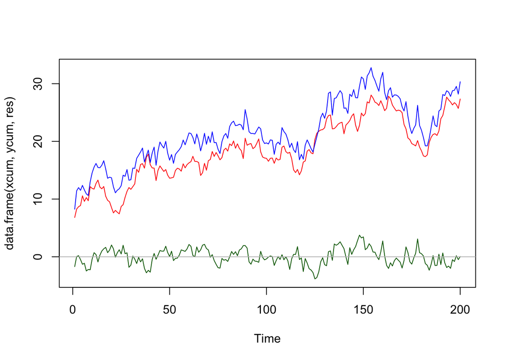

```r
set.seed(3)
err = arima.sim(model = list(order = c(1, 0, 0), ar = 0.68), 200)
#err=rnorm(200)
x = rnorm(err)
xcum = cumsum(x)+5
ycum = xcum+1*err+3
lm(ycum~xcum) %>% residuals -> res
plot.ts(data.frame(xcum, ycum, res), plot.type = "single", col = c("red", "blue", "darkgreen")); abline(h=0, col = "gray")
```

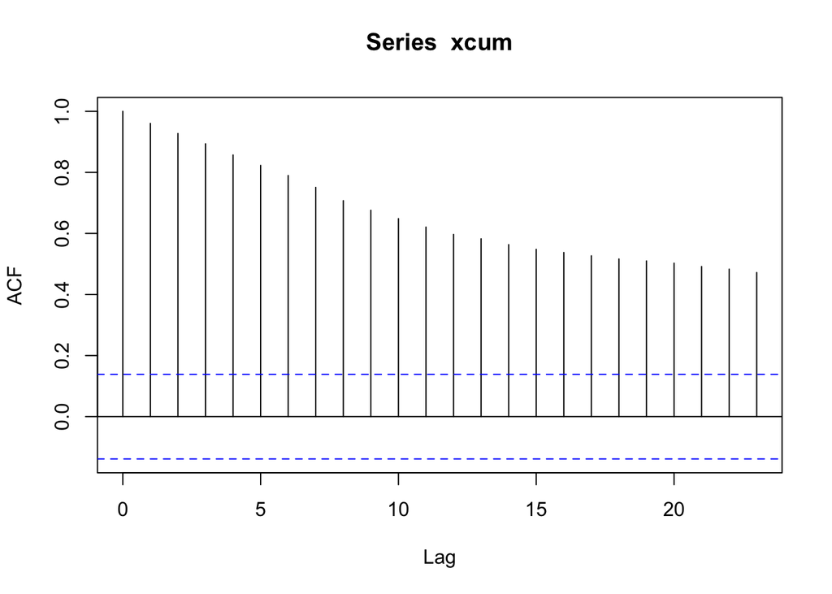

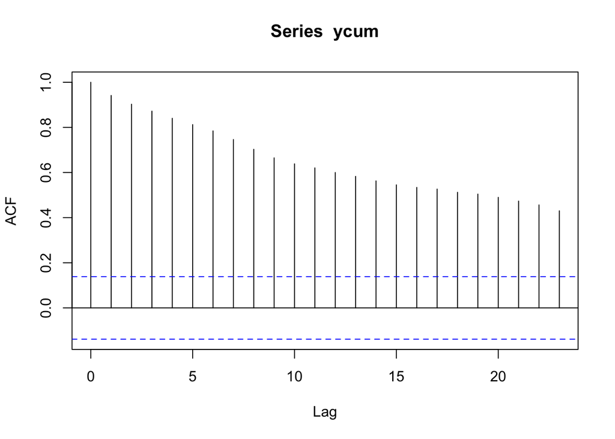

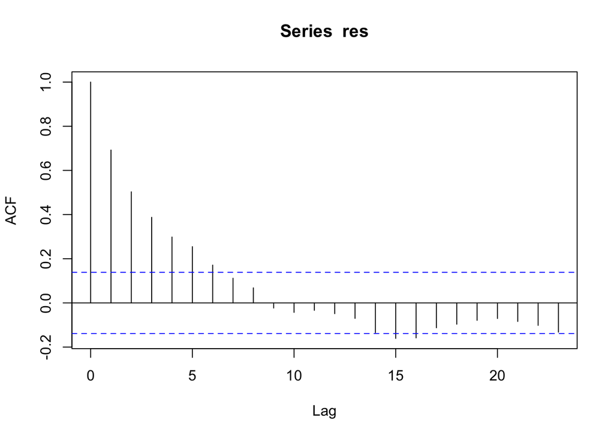

```r
acf(xcum); acf(ycum); acf(res)
```

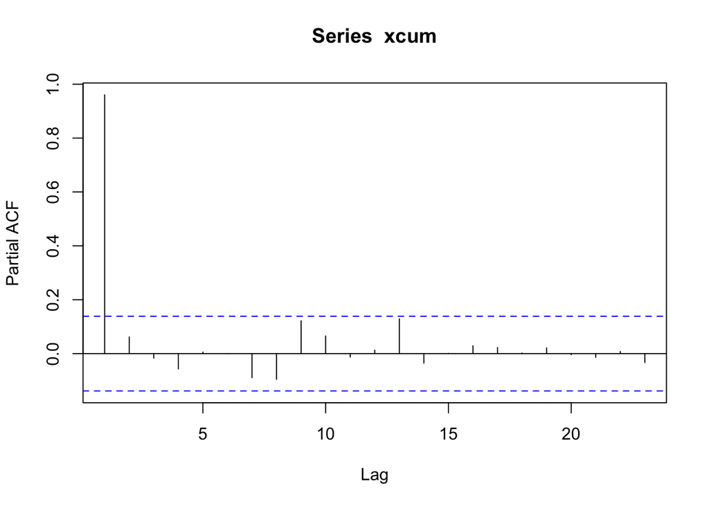

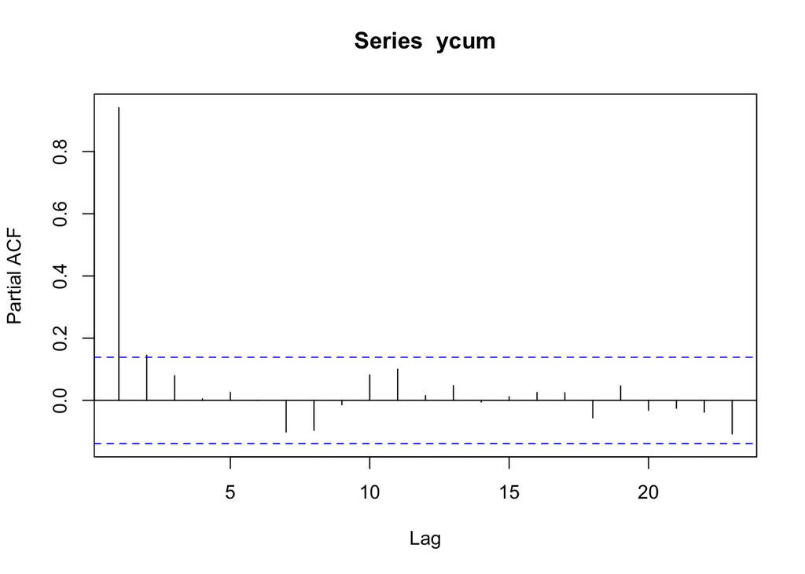

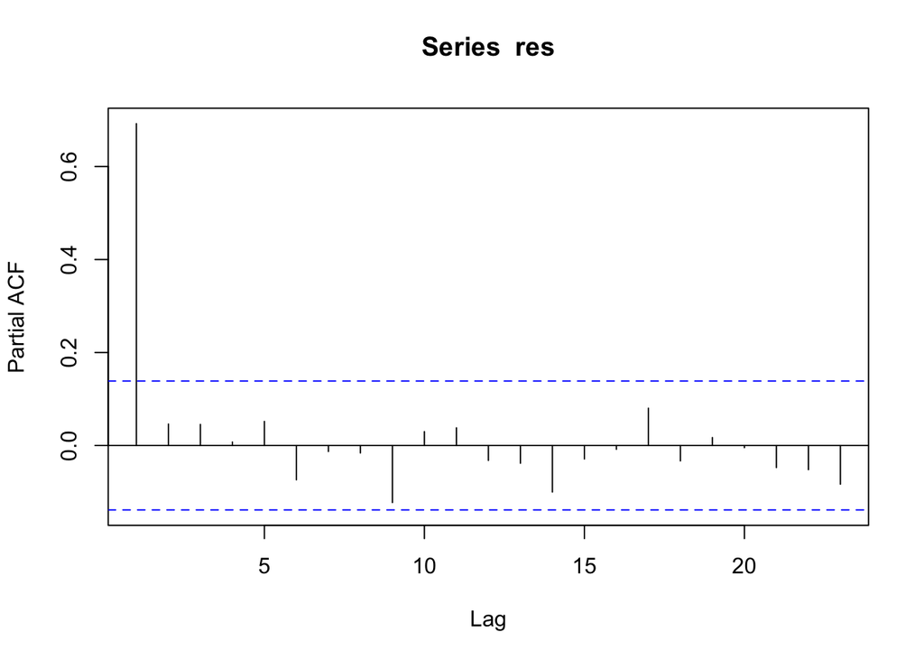

```r
pacf(xcum); pacf(ycum); pacf(res)
```

```r
tseries::adf.test(xcum)
```

```
##
##  Augmented Dickey-Fuller Test
##
## data:  xcum
## Dickey-Fuller = -2.9581, Lag order = 5, p-value = 0.1748
## alternative hypothesis: stationary
```

```r
tseries::adf.test(ycum)
```

```
##
##  Augmented Dickey-Fuller Test
##
## data:  ycum
## Dickey-Fuller = -2.5143, Lag order = 5, p-value = 0.3607
## alternative hypothesis: stationary
```

```r
tseries::adf.test(res)
```

```
##
##  Augmented Dickey-Fuller Test
##
## data:  res
## Dickey-Fuller = -4.098, Lag order = 5, p-value = 0.01
## alternative hypothesis: stationary
```

```r
tseries::adf.test(xcum %>% diff)
```

```
##
##  Augmented Dickey-Fuller Test
##
## data:  xcum %>% diff
## Dickey-Fuller = -4.9585, Lag order = 5, p-value = 0.01
## alternative hypothesis: stationary
```

```r
tseries::adf.test(ycum %>% diff)
```

```
##
##  Augmented Dickey-Fuller Test
##
## data:  ycum %>% diff
## Dickey-Fuller = -5.7188, Lag order = 5, p-value = 0.01
## alternative hypothesis: stationary
```